# Week 3: Building a Portfolio, Part II

R

Author

Robert W. Walker

Published

January 30, 2023

Meeting Date: January 30, 2023

Last updated: 2023-02-06 17:46:20

Timezone: America/Los_Angeles

# Class Plan [Not Necessarily Chronological]

1. AMA
2. Quarto Things
3. Essential Differences between Quarto and RMarkdown
4. Adding to a Portfolio with Quarto, Distil, or Blogdown

Slides: [Week 3 Slides](https://robertwwalker.github.io/CWD-Slides/week-3/index.html)

Readings:

- Quarto Documentation [if not already done]

Links I will work from:

[My Blog](https://rww-science.website) [My Quarto site on Github pages](https://robertwwalker.github.io/)

# Homework

The third assignment has a group component and an individual component.

1. You are to expand your portfolio with at least two pieces of analysis. What analysis? Bits of data visualization or modelling. One should be inspired by a tidyTuesday data visualization, with appropriate citation, and must expand, extend, or in some substantive way deviate from the original.
2. You should also pick a partner and share commentary on improving the aesthetic and the **pitch** of your existing quarto website. There is a thread on discord called `#awesome-quarto` that contains information extending the quarto documentation that you should have read last time. I would strongly encourage you to check it out.

There is also manual reading. The class next time will focus on tables. Here is the selection from the syllabus.

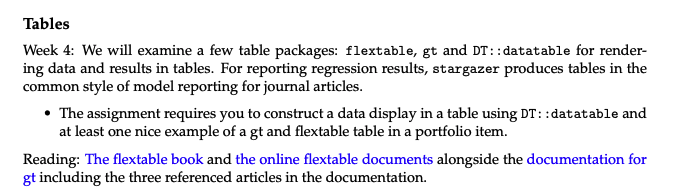

Syllabus Module for Week 4

**Deliverable: an email containing the URLs for the two posts and at least one example of constructive commentary on your partner’s portfolio including their name.**